# EBAIIn2 - ChIP-seq Workshop - Peak annotation

Stephanie Le Gras

2021 May, 27th

## Load data

During this training session we are going to use some features from the package ChIPseeker. Load it.

```r
library(ChIPseeker)
```

Peak files are in narrowPeak format which is of the form ([source](https://genome.ucsc.edu/FAQ/FAQformat.html#format12)):

1. chrom - Name of the chromosome (or contig, scaffold, etc.).
2. chromStart - The starting position of the feature in the chromosome or scaffold. The first base in a chromosome is numbered 0.
3. chromEnd - The ending position of the feature in the chromosome or scaffold. The chromEnd base is not included in the display of the feature. For example, the first 100 bases of a chromosome are defined as chromStart=0, chromEnd=100, and span the bases numbered 0-99.
4. name - Name given to a region (preferably unique). Use “.” if no name is assigned.
5. score - Indicates how dark the peak will be displayed in the browser (0-1000). If all scores were "‘0"’ when the data were submitted to the DCC, the DCC assigned scores 1-1000 based on signal value. Ideally the average signalValue per base spread is between 100-1000.
6. strand - +/- to denote strand or orientation (whenever applicable). Use “.” if no orientation is assigned.
7. signalValue - Measurement of overall (usually, average) enrichment for the region.
8. pValue - Measurement of statistical significance (-log10). Use -1 if no pValue is assigned.
9. qValue - Measurement of statistical significance using false discovery rate (-log10). Use -1 if no qValue is assigned.
10. peak - Point-source called for this peak; 0-based offset from chromStart. Use -1 if no point-source called.

```r
peaks <- list()
peaks[["BRG1"]] <- readPeakFile(params$brg1, as="GRanges")
peaks[["MITF"]] <- readPeakFile(params$mitf, as="GRanges")
peaks[["SOX10"]] <- readPeakFile(params$sox10, as="GRanges")
peaks
```

```
## $BRG1
## GRanges object with 72024 ranges and 7 metadata columns:
##           seqnames            ranges strand |                     V4        V5
##              <Rle>         <IRanges>  <Rle> |            <character> <integer>
##       [1]     chr1     980402-981178      * | BRG1siCTRL_CHIP-seq_..        77
##       [2]     chr1     983476-984526      * | BRG1siCTRL_CHIP-seq_..       108
##       [3]     chr1   1000729-1001179      * | BRG1siCTRL_CHIP-seq_..        90
##       [4]     chr1   1001762-1002054      * | BRG1siCTRL_CHIP-seq_..        40
##       [5]     chr1   1020914-1021207      * | BRG1siCTRL_CHIP-seq_..       114
##       ...      ...               ...    ... .                    ...       ...
##   [72020]     chrY 18936757-18937116      * | BRG1siCTRL_CHIP-seq_..        37
##   [72021]     chrY 19577774-19578316      * | BRG1siCTRL_CHIP-seq_..        73
##   [72022]     chrY 19891214-19892094      * | BRG1siCTRL_CHIP-seq_..       114
##   [72023]     chrY 19892553-19893192      * | BRG1siCTRL_CHIP-seq_..        55
##   [72024]     chrY 21837647-21838039      * | BRG1siCTRL_CHIP-seq_..        55
##                    V6        V7        V8        V9       V10
##           <character> <numeric> <numeric> <numeric> <integer>
##       [1]           .   5.81321  10.22971   7.71662       166
##       [2]           .   5.97792  13.59661  10.83201       384
##       [3]           .   6.65677  11.62894   9.01201       199
##       [4]           .   3.78100   6.17367   4.02109       209
##       [5]           .   8.11634  14.29797  11.46427       158
##       ...         ...       ...       ...       ...       ...
##   [72020]           .   4.53175   5.93549   3.79936       167
##   [72021]           .   6.32404   9.87728   7.38650       165
##   [72022]           .   7.86030  14.29797  11.46427       711
##   [72023]           .   5.29987   7.83781   5.50942       390
##   [72024]           .   5.55592   7.83781   5.50942       152
##   -------
##   seqinfo: 24 sequences from an unspecified genome; no seqlengths
##
## $MITF
## GRanges object with 9702 ranges and 7 metadata columns:
##          seqnames              ranges strand |                     V4        V5
##             <Rle>           <IRanges>  <Rle> |            <character> <integer>
##      [1]     chr1       983745-984004      * |   MITF_CHIP-seq_peak_1        98
##      [2]     chr1     1079458-1079647      * |   MITF_CHIP-seq_peak_2        51
##      [3]     chr1     1304732-1304993      * |   MITF_CHIP-seq_peak_3       138
##      [4]     chr1     1336033-1336207      * |   MITF_CHIP-seq_peak_4        61
##      [5]     chr1     1441628-1441822      * |   MITF_CHIP-seq_peak_5       109
```

[output cut: 37 more lines]

```
##                   V6        V7        V8        V9       V10
##          <character> <numeric> <numeric> <numeric> <integer>
##      [1]           .   4.59920   9.46042   5.84434       105
##      [2]           .   4.82760  13.70010   9.81804        94
##      [3]           .   5.32198  14.34508  10.41972       193
##      [4]           .   9.32479  18.46562  14.31164       357
##      [5]           .   5.57811   7.38611   3.89828        88
##      ...         ...       ...       ...       ...       ...
##   [4534]           .   7.49555  12.81347   8.95567       129
##   [4535]           .   9.73257  17.64072  13.50260       190
##   [4536]           .  10.69129  20.18545  15.91614       177
##   [4537]           .   6.53683  10.55118   6.84047        67
##   [4538]           .   6.21726   9.46355   5.84434       138
##   -------
##   seqinfo: 24 sequences from an unspecified genome; no seqlengths
```

Peaks are stored as **GenomicRanges** objects; this is an R format which look like the bed format, but is optimized in terms of memory requirements and speed of execution.

We can start by computing some basic statistics on the peak sets.

### ChIP-seq data description

#### How many peaks were called?

```r
## check the number of peak sets
length(peaks)
```

```
## [1] 3
```

```r
## compute the number of peaks for all datasets using the list object
sapply(peaks,length)
```

```
##  BRG1  MITF SOX10
## 72024  9702  4538
```

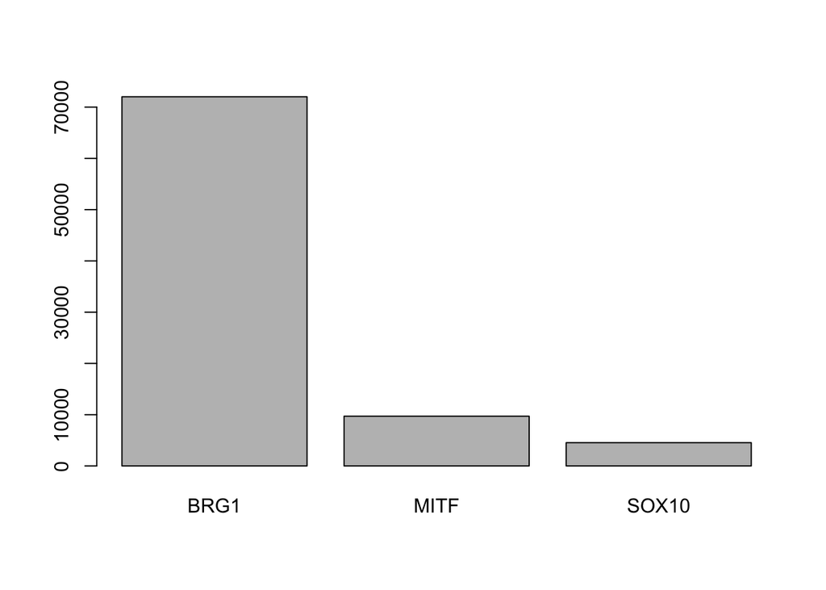

```r
## make a simple barplot
barplot(sapply(peaks,length))
```

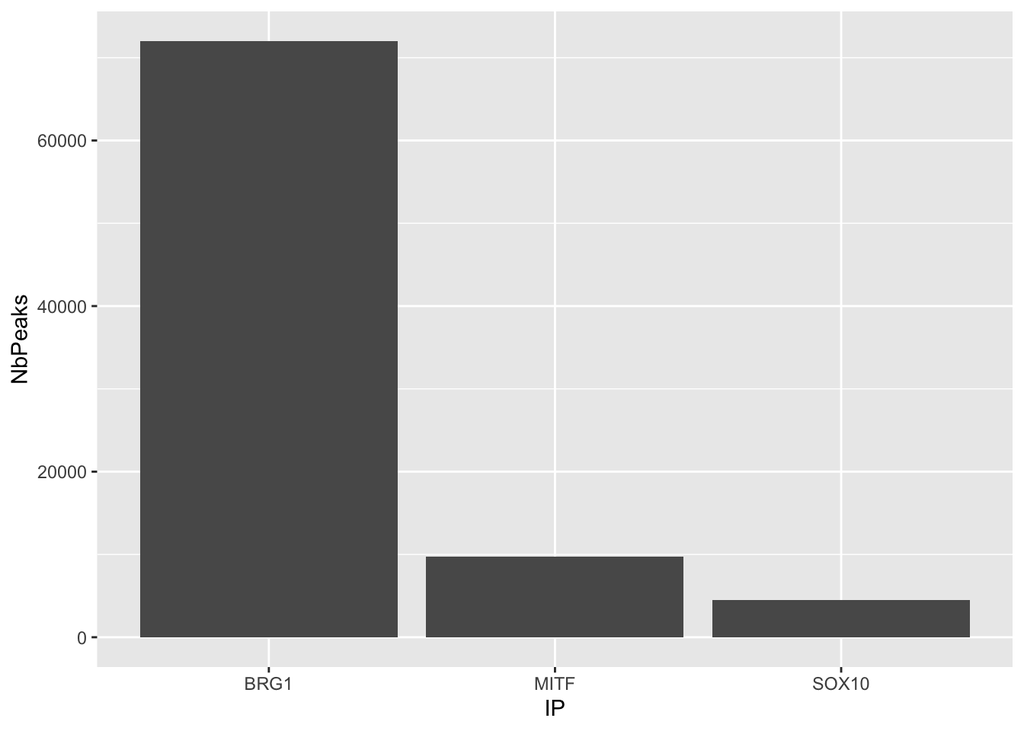

```r
## let's create a barplot with ggplot2 out of this data
# Load ggplot2 library
library(ggplot2)

# create a table with the data to display
# sapply apply the same function (here length) to all elements
# of the list "peaks"
# sapply() function takes list, vector or data frame as input and gives output in vector or matrix
peak.lengths <- data.frame(IP=names(peaks),
                           NbPeaks=sapply(peaks,length))

# make the barplot
ggplot(peak.lengths, aes(x=IP, y=NbPeaks)) +
         geom_bar(stat="identity")
```

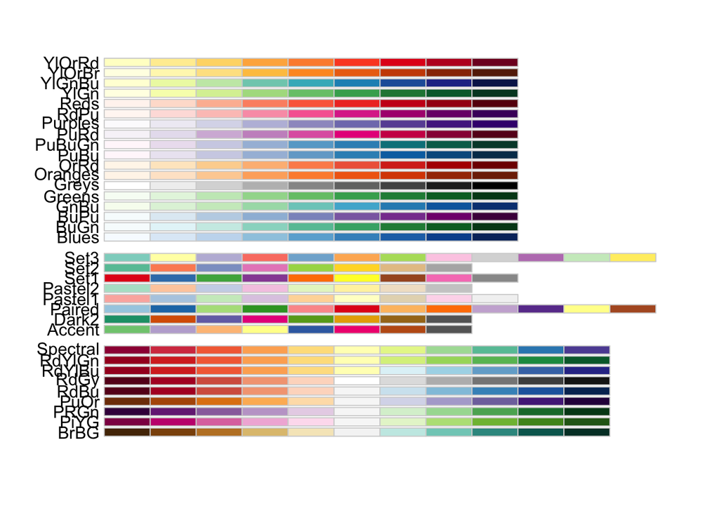

```r
# Let's add colors to the barplot
# In R it exists some already defined colors palettes
# the most widely used palette is RColorBrewer.
# This R library offers several color palettes
# See:
library(RColorBrewer)
par(mar=c(3,4,2,2))
display.brewer.all()
```

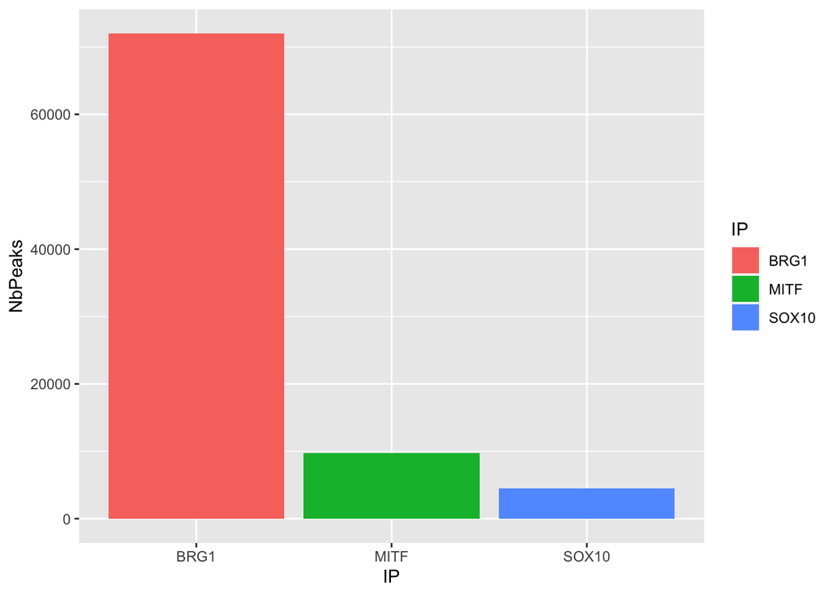

```r
# now lets add colors to the barplot
# first ass the new information, fill=IP to let ggplot know
# that colors change based on chipped protein
ggplot(peak.lengths, aes(x=IP, y=NbPeaks, fill=IP)) +
         geom_bar(stat="identity")
```

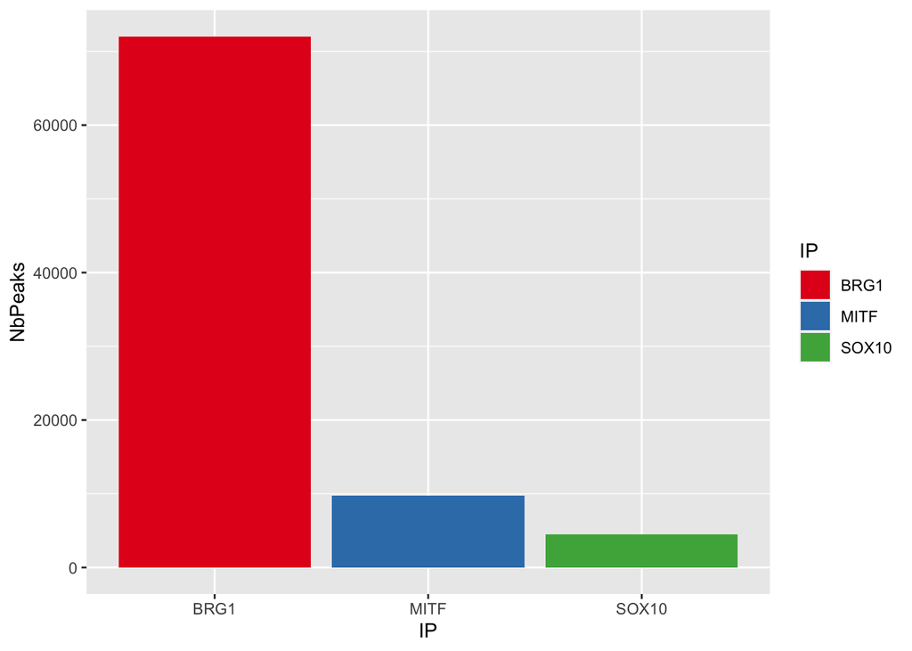

```r
# if we want to use colors from RColorBrewer library
# with the "Set1" color palette
ggplot(peak.lengths, aes(x=IP, y=NbPeaks, fill=IP)) +
         geom_bar(stat="identity")+
         scale_fill_brewer(palette="Set1")
```

#### How large are these peaks?

```r
## statistics on BRG1 peak sizes
## we use the function width() from GenomicRanges
library(GenomicRanges)
summary(width(peaks$BRG1))
```

```
##    Min. 1st Qu.  Median    Mean 3rd Qu.    Max.
##   254.0   308.0   427.0   578.7   671.0  9186.0
```

```r
## get the same for all peaks
## lapply() function is useful for performing operations on list objects and returns a list object of same length of original set.
peak.width = lapply(peaks,width)
lapply(peak.width,summary)
```

```
## $BRG1
##    Min. 1st Qu.  Median    Mean 3rd Qu.    Max.
##   254.0   308.0   427.0   578.7   671.0  9186.0
##
## $MITF
##    Min. 1st Qu.  Median    Mean 3rd Qu.    Max.
##   168.0   186.0   212.0   223.9   245.0  3238.0
##
## $SOX10
##    Min. 1st Qu.  Median    Mean 3rd Qu.    Max.
##   236.0   271.0   323.0   345.3   394.0   937.0
```

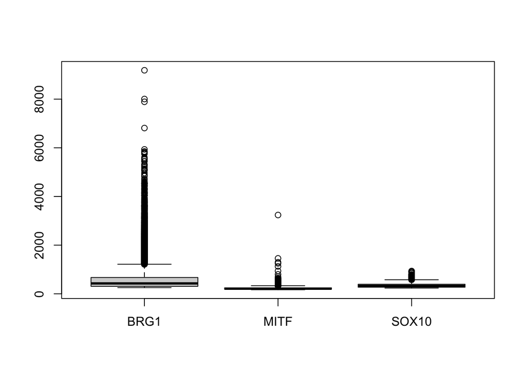

```r
## create a simple boxplot of the peak sizes
boxplot(peak.width)
```

```r
## Create a nice looking boxplot with ggplot2
# ggplot takes a data frame as input.
# we can either create a date frame, this is what we have
# done when we created the barplot. Here, we are going to use a
# package that creates a data frame from other types of data: reshape2
# Load the package
library(reshape2)
peak.width.table <- melt(peak.width)
head(peak.width.table)
```

```
##   value   L1
## 1   777 BRG1
## 2  1051 BRG1
## 3   451 BRG1
## 4   293 BRG1
## 5   294 BRG1
## 6   351 BRG1
```

```r
# in this table, there is as many rows as the total number
# of peaks in all peak sets.
# Number of peaks per chipped protein
sapply(peaks, length)
```

```
##  BRG1  MITF SOX10
## 72024  9702  4538
```

```r
# total number of peaks
sum(sapply(peaks, length))
```

```
## [1] 86264
```

```r
# size of the table we've just generated
dim(peak.width.table)
```

```
## [1] 86264     2
```

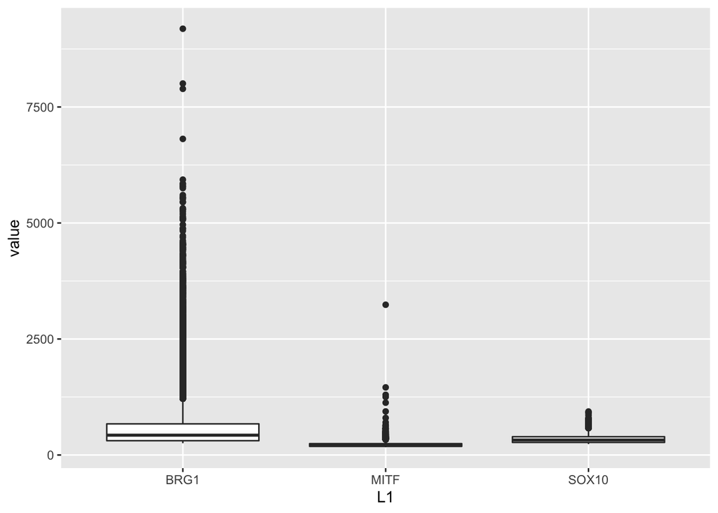

```r
# it contains all possible pairs IP <-> number of peaks possible

# Now create a nice looking boxplot
ggplot(peak.width.table, aes(x=L1, y=value)) +
         geom_boxplot()
```

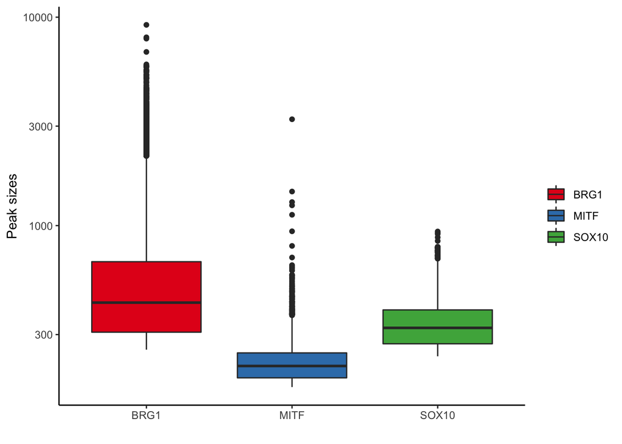

```r
# Enhance it
# - theme_classic() change grey background to white background
# - fill=L1 and scale_fill_brewer(palette="Set1") colors boxplots
# based on chipped protein and with colors from RColorBrewer Set1 palette
# - labs changes x and y axis labels and legend title
# - scale_y_log10() set y axis to a log scale so that we can have a nice
# view of the data in small values
ggplot(peak.width.table, aes(x=L1, y=value, fill=L1)) +
         geom_boxplot()+
         theme_classic()+
         scale_fill_brewer(palette="Set1")+
         labs(x = "", y = "Peak sizes", fill = "")+
         scale_y_log10()
```

### Where are the peaks located over the whole genome?

We can now display the genomic distribution of the peaks along the chromosomes, including the peak scores, using the `covplot` function from `ChIPSeeker`:

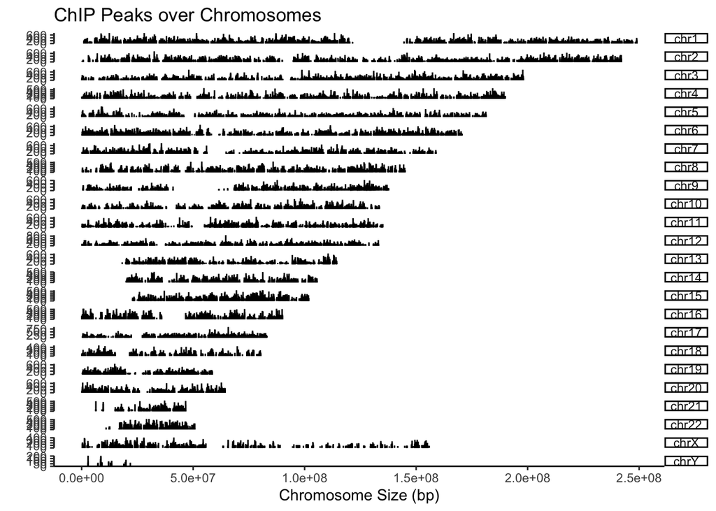

```r
# genome wide BRG1 peak distribution
covplot(peaks$BRG1, weightCol="V5")
```

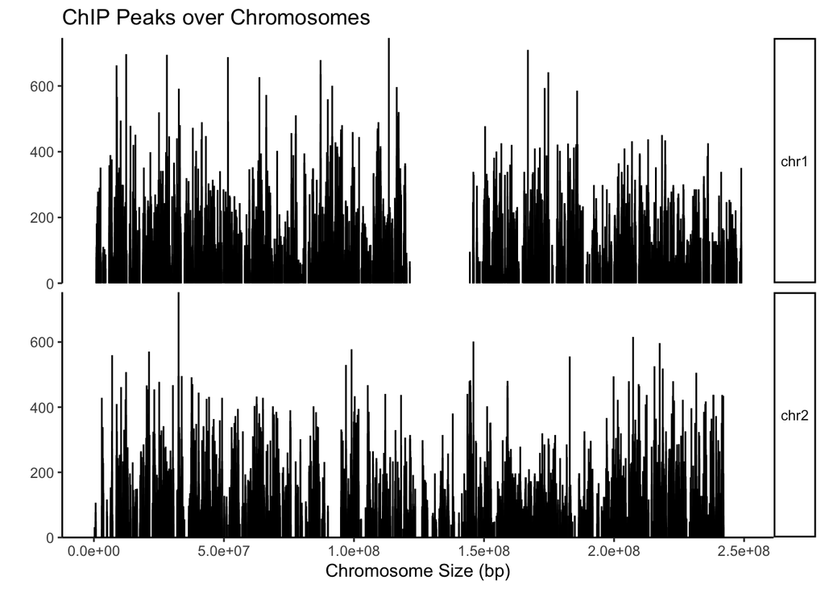

```r
# chromosome wide BRG1 peak distribution
covplot(peaks$BRG1, chrs=c("chr1", "chr2"), weightCol="V5")
```

### How does the signal look like at TSS?

In addition to the genome wide plot, we can check if there is a tendency for the peaks to be located close to gene promoters. Here promoters are defined as regions +/-5Kb around the TSS.

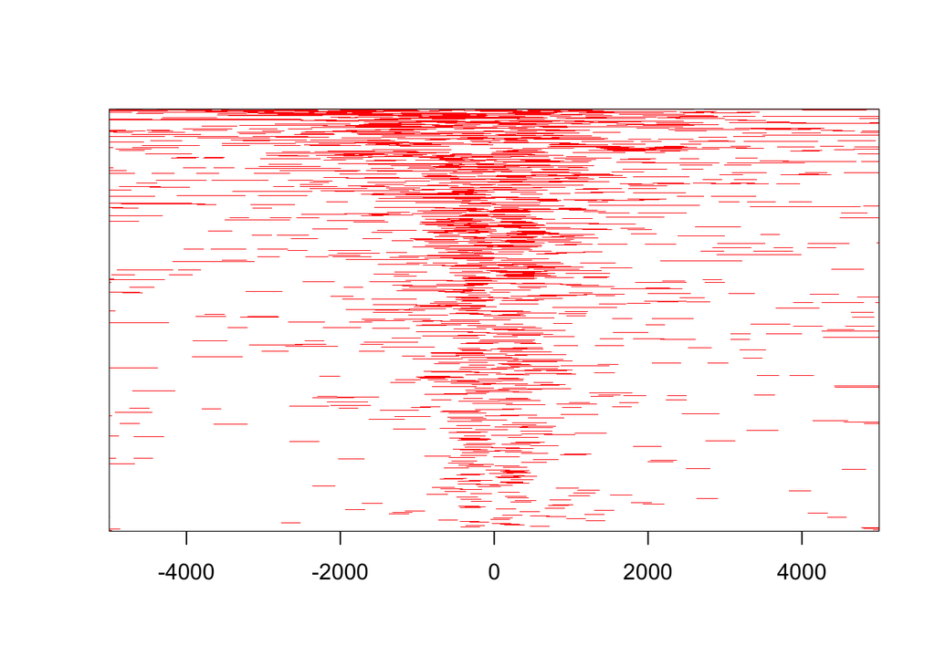

```r
## Load transcript annotation
library(TxDb.Hsapiens.UCSC.hg38.knownGene)
txdb <- TxDb.Hsapiens.UCSC.hg38.knownGene

## define gene promoters
## TxDb object should be passed for peak annotation (see below)
promoter = getPromoters(TxDb=txdb, upstream=5000, downstream=5000)

## compute the density of peaks within the promoter regions
tagMatrix = getTagMatrix(peaks$BRG1, windows=promoter)

## plot the density
tagHeatmap(tagMatrix, xlim=c(-5000, 5000), color="red")
```

The TxDb class is a container for storing transcript annotations. Bioconductor provides several packages containing TxDb objects for model organisms sur as Human and mouse. For instance, TxDb.Hsapiens.UCSC.hg38.knownGene, TxDb.Hsapiens.UCSC.hg19.knownGene for human genome hg38 and hg19, TxDb.Mmusculus.UCSC.mm10.knownGene and TxDb.Mmusculus.UCSC.mm9.knownGene for mouse genome mm10 and mm9, etc. User can also prepare their own TxDb by retrieving information from UCSC Genome Bioinformatics and BioMart data resources by R function makeTxDbFromBiomart and makeTxDbFromUCSC. One can also create a TxDb objects for his favourite organism using an annotation file in GTF/GFF format using the function makeTxDbFromGFF or the package GenomicFeatures.

```r
## download GTF file
download.file("https://ftp.ncbi.nlm.nih.gov/genomes/all/annotation_releases/93934/101/GCF_001577835.2_Coturnix_japonica_2.1/GCF_001577835.2_Coturnix_japonica_2.1_genomic.gtf.gz", "Coturnix_japonica_2.1.annotation.gtf.gz")

## Build TxDb object
library(GenomicFeatures)
txdb = makeTxDbFromGFF("Coturnix_japonica_2.1.annotation.gtf.gz")

## To save the txdb database
library(AnnotationDbi)
saveDb(txdb, 'txdb.Coturnix_japonica_2.1.sqlite')

## load it when needed
library(AnnotationDbi)
txdb = loadDb(file = 'txdb.Coturnix_japonica_2.1.sqlite')
```

### Functional annotation of the peaks

We can now assign the peaks to the closest genes and genomic features (introns, exons, promoters, distal regions, etc…). This is done using the function `annotatePeak` which compares peak positions with the genomic feature positions of the reference genome. This function returns a complex object which contains all this information.

```r
## org.Hs.eg.db is an R object that contains mappings between Entrez Gene identifiers and GenBank accession numbers.
library(org.Hs.eg.db)

## Annotate peaks for all datasets and store it in a list
peakAnno <- list()
peakAnno[["BRG1"]] = annotatePeak(peaks$BRG1, tssRegion=c(-1000, 100), TxDb=txdb, annoDb="org.Hs.eg.db")
```

```
## >> preparing features information...      2021-05-11 14:59:05
## >> identifying nearest features...        2021-05-11 14:59:10
## >> calculating distance from peak to TSS...   2021-05-11 14:59:18
## >> assigning genomic annotation...        2021-05-11 14:59:18
## >> adding gene annotation...          2021-05-11 15:01:26
## >> assigning chromosome lengths           2021-05-11 15:01:28
## >> done...                    2021-05-11 15:01:28
```

```r
peakAnno[["MITF"]] = annotatePeak(peaks$MITF, tssRegion=c(-1000, 100), TxDb=txdb, annoDb="org.Hs.eg.db")
```

```
## >> preparing features information...      2021-05-11 15:01:29
## >> identifying nearest features...        2021-05-11 15:01:29
## >> calculating distance from peak to TSS...   2021-05-11 15:01:31
## >> assigning genomic annotation...        2021-05-11 15:01:31
## >> adding gene annotation...          2021-05-11 15:01:48
## >> assigning chromosome lengths           2021-05-11 15:01:48
## >> done...                    2021-05-11 15:01:49
```

```r
peakAnno[["SOX10"]] = annotatePeak(peaks$SOX10, tssRegion=c(-1000, 100), TxDb=txdb, annoDb="org.Hs.eg.db")
```

```
## >> preparing features information...      2021-05-11 15:01:49
## >> identifying nearest features...        2021-05-11 15:01:49
## >> calculating distance from peak to TSS...   2021-05-11 15:01:51
## >> assigning genomic annotation...        2021-05-11 15:01:51
## >> adding gene annotation...          2021-05-11 15:02:10
## >> assigning chromosome lengths           2021-05-11 15:02:10
## >> done...                    2021-05-11 15:02:10
```

#### Genomic localization

We can now analyze more in details the genomic features associated to our peaks (introns, exons, promoters, distal regions,…)

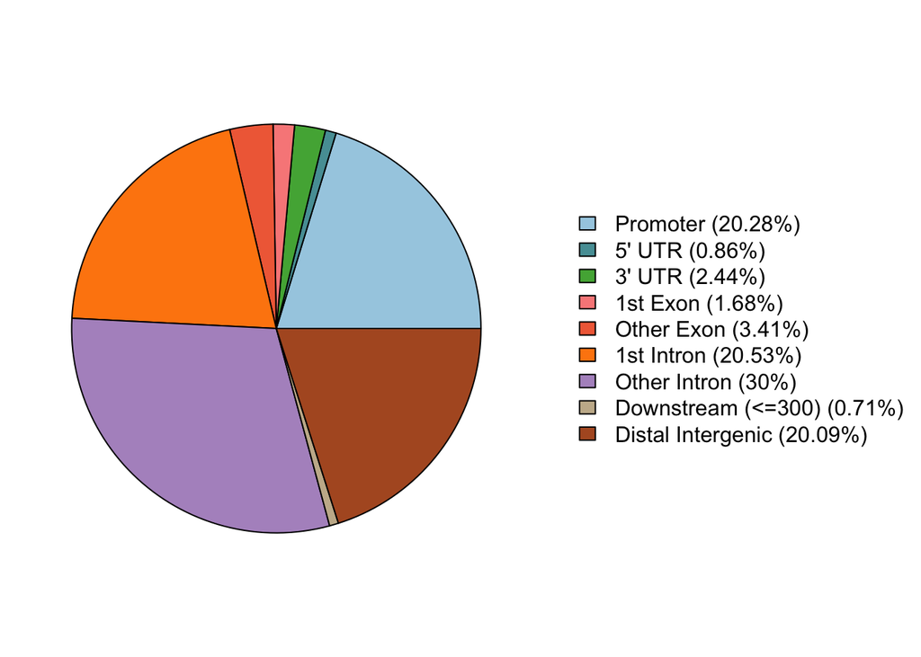

```r
## distribution of genomic features for BRG1 peaks
# as a pie chart - which is the most widely used representation in publication
plotAnnoPie(peakAnno$BRG1)
```

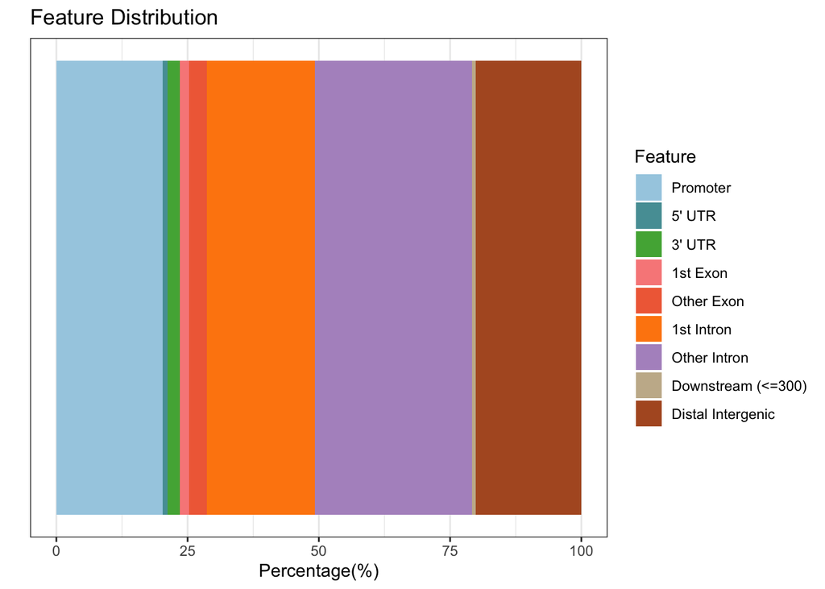

```r
# as a barplot
plotAnnoBar(peakAnno$BRG1)
```

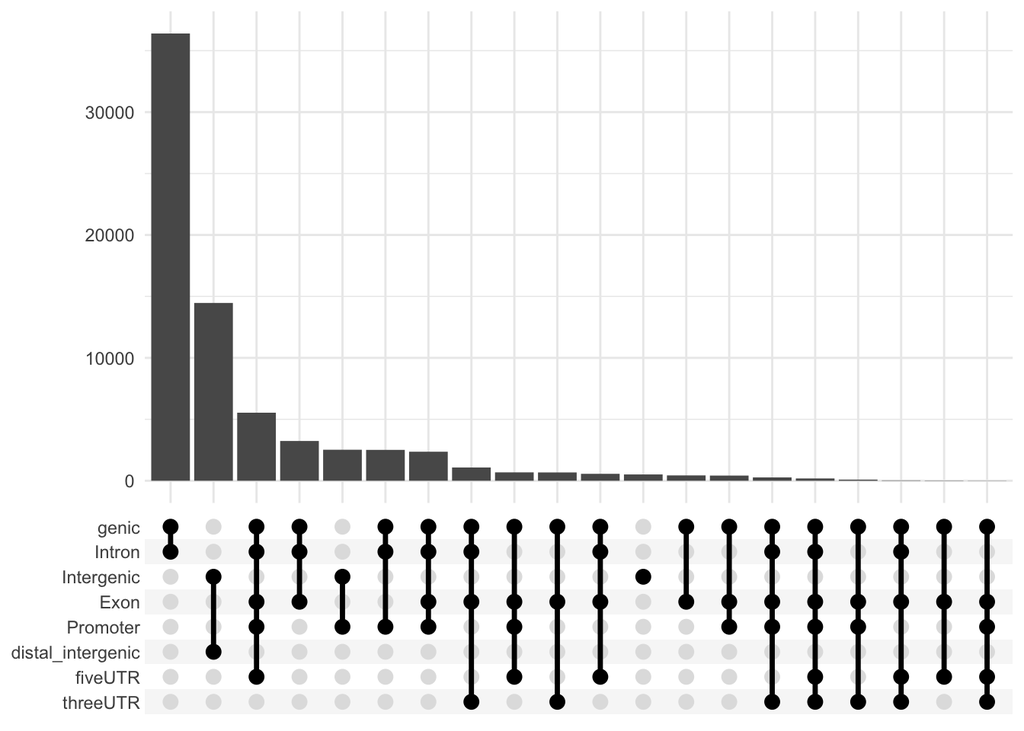

```r
# However since some annotation overlap, ChIPseeker provides functions that help having a view of full annotation overlap
library(UpSetR)
upsetplot(peakAnno$BRG1)
```

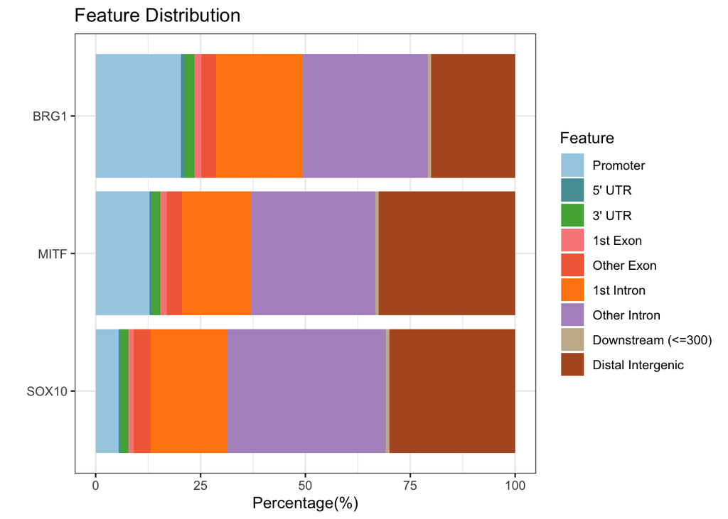

```r
## Representation with barplot is the most convenient view when looking
## at several datasets at once
## show the distribution of genomic features for all peak sets at once
plotAnnoBar(peakAnno)
```